# Risk Factor Analysis

## Outcome Variable

**Outcome Variable:** ever_swasted

## Predictor Variables

**Intervention Variable:** parity

**Adjustment Set:**

- arm
- W_mage
- meducyrs
- feducyrs
- hhwealth_quart
- W_mhtcm
- vagbrth
- W_nrooms
- impsan
- delta_W_mage
- delta_meducyrs
- delta_feducyrs
- delta_hhwealth_quart
- delta_W_mhtcm
- delta_vagbrth
- delta_W_nrooms
- delta_impsan

## Stratifying Variables

The analysis was stratified on these variable(s):

- agecat
- studyid
- country

## Data Summary

| agecat | studyid | country | parity | ever_swasted | n_cell | n |
| --- | --- | --- | --- | --- | --- | --- |
| 0-24 months | ki1000304b-SAS-CompFeed | INDIA | 1 | 0 | 400 | 1513 |
| 0-24 months | ki1000304b-SAS-CompFeed | INDIA | 1 | 1 | 48 | 1513 |
| 0-24 months | ki1000304b-SAS-CompFeed | INDIA | 2 | 0 | 300 | 1513 |
| 0-24 months | ki1000304b-SAS-CompFeed | INDIA | 2 | 1 | 54 | 1513 |
| 0-24 months | ki1000304b-SAS-CompFeed | INDIA | 3+ | 0 | 590 | 1513 |
| 0-24 months | ki1000304b-SAS-CompFeed | INDIA | 3+ | 1 | 121 | 1513 |
| 0-24 months | ki1000304b-SAS-FoodSuppl | INDIA | 1 | 0 | 70 | 397 |
| 0-24 months | ki1000304b-SAS-FoodSuppl | INDIA | 1 | 1 | 7 | 397 |
| 0-24 months | ki1000304b-SAS-FoodSuppl | INDIA | 2 | 0 | 79 | 397 |
| 0-24 months | ki1000304b-SAS-FoodSuppl | INDIA | 2 | 1 | 13 | 397 |
| 0-24 months | ki1000304b-SAS-FoodSuppl | INDIA | 3+ | 0 | 181 | 397 |
| 0-24 months | ki1000304b-SAS-FoodSuppl | INDIA | 3+ | 1 | 47 | 397 |
| 0-24 months | ki1017093b-PROVIDE | BANGLADESH | 1 | 0 | 252 | 700 |
| 0-24 months | ki1017093b-PROVIDE | BANGLADESH | 1 | 1 | 19 | 700 |
| 0-24 months | ki1017093b-PROVIDE | BANGLADESH | 2 | 0 | 236 | 700 |
| 0-24 months | ki1017093b-PROVIDE | BANGLADESH | 2 | 1 | 8 | 700 |
| 0-24 months | ki1017093b-PROVIDE | BANGLADESH | 3+ | 0 | 170 | 700 |
| 0-24 months | ki1017093b-PROVIDE | BANGLADESH | 3+ | 1 | 15 | 700 |
| 0-24 months | ki1066203-TanzaniaChild2 | TANZANIA, UNITED REPUBLIC OF | 1 | 0 | 767 | 2357 |
| 0-24 months | ki1066203-TanzaniaChild2 | TANZANIA, UNITED REPUBLIC OF | 1 | 1 | 54 | 2357 |
| 0-24 months | ki1066203-TanzaniaChild2 | TANZANIA, UNITED REPUBLIC OF | 2 | 0 | 717 | 2357 |
| 0-24 months | ki1066203-TanzaniaChild2 | TANZANIA, UNITED REPUBLIC OF | 2 | 1 | 54 | 2357 |
| 0-24 months | ki1066203-TanzaniaChild2 | TANZANIA, UNITED REPUBLIC OF | 3+ | 0 | 716 | 2357 |
| 0-24 months | ki1066203-TanzaniaChild2 | TANZANIA, UNITED REPUBLIC OF | 3+ | 1 | 49 | 2357 |
| 0-24 months | ki1101329-Keneba | GAMBIA | 1 | 0 | 208 | 1989 |
| 0-24 months | ki1101329-Keneba | GAMBIA | 1 | 1 | 32 | 1989 |
| 0-24 months | ki1101329-Keneba | GAMBIA | 2 | 0 | 184 | 1989 |
| 0-24 months | ki1101329-Keneba | GAMBIA | 2 | 1 | 30 | 1989 |
| 0-24 months | ki1101329-Keneba | GAMBIA | 3+ | 0 | 1279 | 1989 |
| 0-24 months | ki1101329-Keneba | GAMBIA | 3+ | 1 | 256 | 1989 |

[output cut: 168 more lines]

The following strata were considered:

- agecat: 0-24 months, studyid: ki1000304b-SAS-CompFeed, country: INDIA
- agecat: 0-24 months, studyid: ki1000304b-SAS-FoodSuppl, country: INDIA
- agecat: 0-24 months, studyid: ki1017093b-PROVIDE, country: BANGLADESH
- agecat: 0-24 months, studyid: ki1066203-TanzaniaChild2, country: TANZANIA, UNITED REPUBLIC OF
- agecat: 0-24 months, studyid: ki1101329-Keneba, country: GAMBIA
- agecat: 0-24 months, studyid: ki1113344-GMS-Nepal, country: NEPAL
- agecat: 0-24 months, studyid: ki1126311-ZVITAMBO, country: ZIMBABWE
- agecat: 0-24 months, studyid: ki1135781-COHORTS, country: GUATEMALA
- agecat: 0-24 months, studyid: ki1135781-COHORTS, country: INDIA
- agecat: 0-24 months, studyid: ki1135781-COHORTS, country: PHILIPPINES
- agecat: 0-24 months, studyid: kiGH5241-JiVitA-3, country: BANGLADESH
- agecat: 0-6 months, studyid: ki1000304b-SAS-CompFeed, country: INDIA
- agecat: 0-6 months, studyid: ki1000304b-SAS-FoodSuppl, country: INDIA
- agecat: 0-6 months, studyid: ki1017093b-PROVIDE, country: BANGLADESH
- agecat: 0-6 months, studyid: ki1066203-TanzaniaChild2, country: TANZANIA, UNITED REPUBLIC OF
- agecat: 0-6 months, studyid: ki1101329-Keneba, country: GAMBIA
- agecat: 0-6 months, studyid: ki1113344-GMS-Nepal, country: NEPAL
- agecat: 0-6 months, studyid: ki1126311-ZVITAMBO, country: ZIMBABWE
- agecat: 0-6 months, studyid: ki1135781-COHORTS, country: GUATEMALA
- agecat: 0-6 months, studyid: ki1135781-COHORTS, country: INDIA
- agecat: 0-6 months, studyid: ki1135781-COHORTS, country: PHILIPPINES
- agecat: 0-6 months, studyid: kiGH5241-JiVitA-3, country: BANGLADESH
- agecat: 6-24 months, studyid: ki1000304b-SAS-CompFeed, country: INDIA
- agecat: 6-24 months, studyid: ki1000304b-SAS-FoodSuppl, country: INDIA
- agecat: 6-24 months, studyid: ki1017093b-PROVIDE, country: BANGLADESH
- agecat: 6-24 months, studyid: ki1066203-TanzaniaChild2, country: TANZANIA, UNITED REPUBLIC OF
- agecat: 6-24 months, studyid: ki1101329-Keneba, country: GAMBIA
- agecat: 6-24 months, studyid: ki1113344-GMS-Nepal, country: NEPAL
- agecat: 6-24 months, studyid: ki1126311-ZVITAMBO, country: ZIMBABWE
- agecat: 6-24 months, studyid: ki1135781-COHORTS, country: GUATEMALA
- agecat: 6-24 months, studyid: ki1135781-COHORTS, country: INDIA
- agecat: 6-24 months, studyid: ki1135781-COHORTS, country: PHILIPPINES
- agecat: 6-24 months, studyid: kiGH5241-JiVitA-3, country: BANGLADESH

### Dropped Strata

Some strata were dropped due to rare outcomes:

- agecat: 0-6 months, studyid: ki1000304b-SAS-FoodSuppl, country: INDIA
- agecat: 0-6 months, studyid: ki1017093b-PROVIDE, country: BANGLADESH
- agecat: 6-24 months, studyid: ki1017093b-PROVIDE, country: BANGLADESH

## Methods Detail

We’re interested in the causal parameters $E[Y_a]$ for all values of $a \in \mathcal{A}$. These parameters represent the mean outcome if, possibly contrary to fact, we intervened to set all units to have $A=a$. Under the randomization and positivity assumptions, these are identified by the statistical parameters $\psi_a=E_W[E_{Y|A,W}(Y|A=a,W)]$. In addition, we’re interested in the mean of $Y$, $E[Y]$ under no intervention (the observed mean). We will estimate these parameters by using SuperLearner to fit the relevant likelihood factors – $E_{Y|A,W}(Y|A=a,W)$ and $p(A=a|W)$, and then updating our likelihood fit using a joint TMLE.

For unadjusted analyses ($W=\{\}$), initial likelihoods were estimated using Lrnr_glm to estimate the simple $E(Y|A)$ and Lrnr_mean to estimate $p(A)$. For adjusted analyses, a small library containing Lrnr_glmnet, Lrnr_xgboost, and Lrnr_mean was used.

Having estimated these parameters, we will then use the delta method to estimate relative risks and attributable risks relative to a prespecified baseline level of $A$.

# Results Detail

## Results Plots

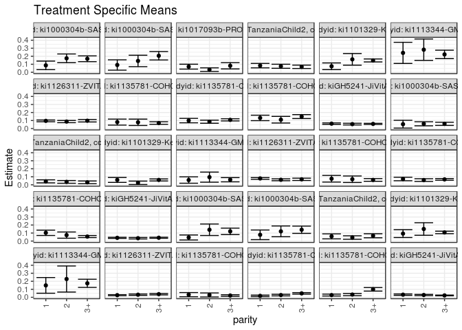

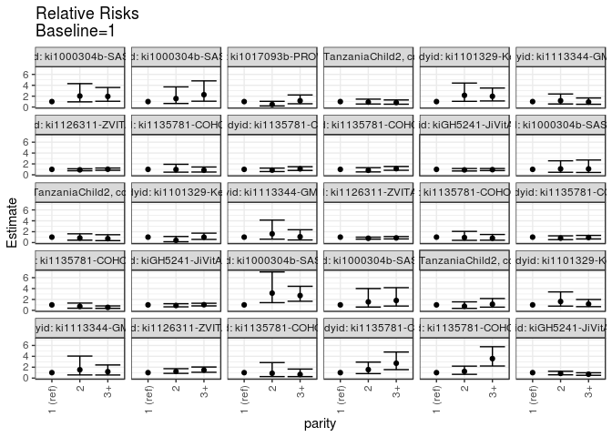

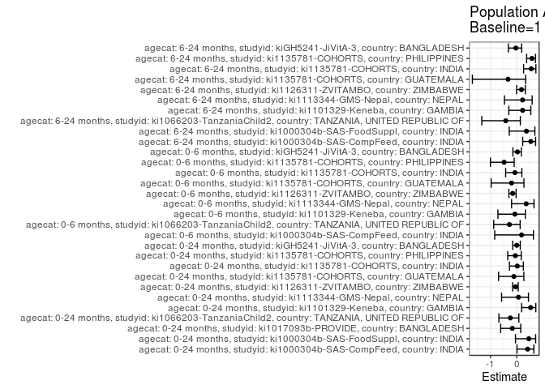

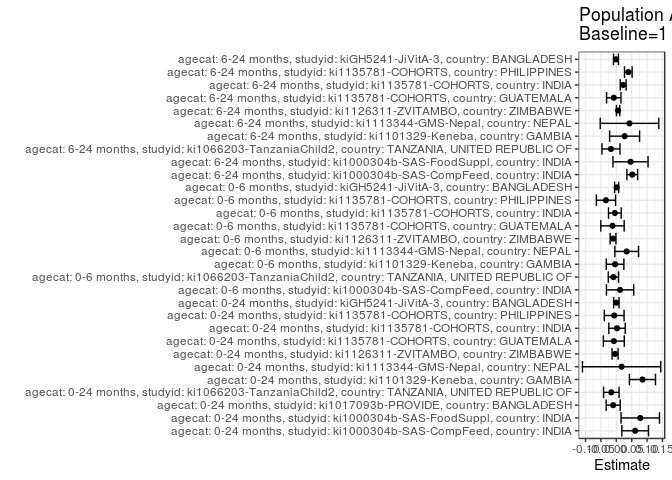

## Results Table

### Parameter: TSM

| agecat | studyid | country | intervention_level | baseline_level | estimate | ci_lower | ci_upper |
| --- | --- | --- | --- | --- | --- | --- | --- |
| 0-24 months | ki1000304b-SAS-CompFeed | INDIA | 1 | NA | 0.0861180 | 0.0328826 | 0.1393533 |
| 0-24 months | ki1000304b-SAS-CompFeed | INDIA | 2 | NA | 0.1745396 | 0.1206486 | 0.2284307 |
| 0-24 months | ki1000304b-SAS-CompFeed | INDIA | 3+ | NA | 0.1683977 | 0.1323457 | 0.2044497 |
| 0-24 months | ki1000304b-SAS-FoodSuppl | INDIA | 1 | NA | 0.0909091 | 0.0266170 | 0.1552012 |
| 0-24 months | ki1000304b-SAS-FoodSuppl | INDIA | 2 | NA | 0.1413043 | 0.0700356 | 0.2125731 |
| 0-24 months | ki1000304b-SAS-FoodSuppl | INDIA | 3+ | NA | 0.2061404 | 0.1535651 | 0.2587156 |
| 0-24 months | ki1017093b-PROVIDE | BANGLADESH | 1 | NA | 0.0701107 | 0.0396891 | 0.1005323 |
| 0-24 months | ki1017093b-PROVIDE | BANGLADESH | 2 | NA | 0.0327869 | 0.0104267 | 0.0551470 |
| 0-24 months | ki1017093b-PROVIDE | BANGLADESH | 3+ | NA | 0.0810811 | 0.0417196 | 0.1204425 |
| 0-24 months | ki1066203-TanzaniaChild2 | TANZANIA, UNITED REPUBLIC OF | 1 | NA | 0.0828096 | 0.0551141 | 0.1105051 |
| 0-24 months | ki1066203-TanzaniaChild2 | TANZANIA, UNITED REPUBLIC OF | 2 | NA | 0.0748809 | 0.0495791 | 0.1001827 |
| 0-24 months | ki1066203-TanzaniaChild2 | TANZANIA, UNITED REPUBLIC OF | 3+ | NA | 0.0682237 | 0.0469426 | 0.0895049 |
| 0-24 months | ki1101329-Keneba | GAMBIA | 1 | NA | 0.0749008 | 0.0331574 | 0.1166442 |
| 0-24 months | ki1101329-Keneba | GAMBIA | 2 | NA | 0.1612386 | 0.0886508 | 0.2338264 |
| 0-24 months | ki1101329-Keneba | GAMBIA | 3+ | NA | 0.1476338 | 0.1291872 | 0.1660804 |
| 0-24 months | ki1113344-GMS-Nepal | NEPAL | 1 | NA | 0.2418828 | 0.1103034 | 0.3734622 |
| 0-24 months | ki1113344-GMS-Nepal | NEPAL | 2 | NA | 0.2816973 | 0.1480807 | 0.4153139 |
| 0-24 months | ki1113344-GMS-Nepal | NEPAL | 3+ | NA | 0.2229575 | 0.1703688 | 0.2755463 |
| 0-24 months | ki1126311-ZVITAMBO | ZIMBABWE | 1 | NA | 0.0955780 | 0.0846485 | 0.1065076 |
| 0-24 months | ki1126311-ZVITAMBO | ZIMBABWE | 2 | NA | 0.0868951 | 0.0729282 | 0.1008620 |
| 0-24 months | ki1126311-ZVITAMBO | ZIMBABWE | 3+ | NA | 0.0975583 | 0.0819311 | 0.1131855 |
| 0-24 months | ki1135781-COHORTS | GUATEMALA | 1 | NA | 0.0803302 | 0.0429828 | 0.1176775 |
| 0-24 months | ki1135781-COHORTS | GUATEMALA | 2 | NA | 0.0779640 | 0.0384350 | 0.1174930 |
| 0-24 months | ki1135781-COHORTS | GUATEMALA | 3+ | NA | 0.0685331 | 0.0523997 | 0.0846665 |
| 0-24 months | ki1135781-COHORTS | INDIA | 1 | NA | 0.0990946 | 0.0712449 | 0.1269442 |
| 0-24 months | ki1135781-COHORTS | INDIA | 2 | NA | 0.0852374 | 0.0660048 | 0.1044700 |
| 0-24 months | ki1135781-COHORTS | INDIA | 3+ | NA | 0.1082078 | 0.0947823 | 0.1216333 |
| 0-24 months | ki1135781-COHORTS | PHILIPPINES | 1 | NA | 0.1323214 | 0.0982998 | 0.1663430 |
| 0-24 months | ki1135781-COHORTS | PHILIPPINES | 2 | NA | 0.1102462 | 0.0688001 | 0.1516922 |
| 0-24 months | ki1135781-COHORTS | PHILIPPINES | 3+ | NA | 0.1491245 | 0.1247466 | 0.1735023 |

[output cut: 60 more lines]

### Parameter: E(Y)

| agecat | studyid | country | intervention_level | baseline_level | estimate | ci_lower | ci_upper |
| --- | --- | --- | --- | --- | --- | --- | --- |
| 0-24 months | ki1000304b-SAS-CompFeed | INDIA | NA | NA | 0.1473893 | 0.1184132 | 0.1763654 |
| 0-24 months | ki1000304b-SAS-FoodSuppl | INDIA | NA | NA | 0.1687657 | 0.1318761 | 0.2056554 |
| 0-24 months | ki1017093b-PROVIDE | BANGLADESH | NA | NA | 0.0600000 | 0.0423945 | 0.0776055 |
| 0-24 months | ki1066203-TanzaniaChild2 | TANZANIA, UNITED REPUBLIC OF | NA | NA | 0.0666101 | 0.0565417 | 0.0766785 |
| 0-24 months | ki1101329-Keneba | GAMBIA | NA | NA | 0.1598793 | 0.1437689 | 0.1759898 |
| 0-24 months | ki1113344-GMS-Nepal | NEPAL | NA | NA | 0.2591362 | 0.2241059 | 0.2941665 |
| 0-24 months | ki1126311-ZVITAMBO | ZIMBABWE | NA | NA | 0.0915483 | 0.0867604 | 0.0963361 |
| 0-24 months | ki1135781-COHORTS | GUATEMALA | NA | NA | 0.0723341 | 0.0584645 | 0.0862036 |
| 0-24 months | ki1135781-COHORTS | INDIA | NA | NA | 0.1014273 | 0.0927249 | 0.1101298 |
| 0-24 months | ki1135781-COHORTS | PHILIPPINES | NA | NA | 0.1254516 | 0.1136848 | 0.1372183 |
| 0-24 months | kiGH5241-JiVitA-3 | BANGLADESH | NA | NA | 0.0609616 | 0.0574870 | 0.0644361 |
| 0-6 months | ki1000304b-SAS-CompFeed | INDIA | NA | NA | 0.0664452 | 0.0425975 | 0.0902929 |
| 0-6 months | ki1066203-TanzaniaChild2 | TANZANIA, UNITED REPUBLIC OF | NA | NA | 0.0335172 | 0.0262496 | 0.0407848 |
| 0-6 months | ki1101329-Keneba | GAMBIA | NA | NA | 0.0565313 | 0.0459241 | 0.0671385 |
| 0-6 months | ki1113344-GMS-Nepal | NEPAL | NA | NA | 0.0930233 | 0.0698010 | 0.1162455 |
| 0-6 months | ki1126311-ZVITAMBO | ZIMBABWE | NA | NA | 0.0686841 | 0.0644712 | 0.0728970 |
| 0-6 months | ki1135781-COHORTS | GUATEMALA | NA | NA | 0.0630292 | 0.0484135 | 0.0776449 |
| 0-6 months | ki1135781-COHORTS | INDIA | NA | NA | 0.0675068 | 0.0601293 | 0.0748842 |
| 0-6 months | ki1135781-COHORTS | PHILIPPINES | NA | NA | 0.0693167 | 0.0602923 | 0.0783411 |
| 0-6 months | kiGH5241-JiVitA-3 | BANGLADESH | NA | NA | 0.0413220 | 0.0383449 | 0.0442991 |
| 6-24 months | ki1000304b-SAS-CompFeed | INDIA | NA | NA | 0.0964723 | 0.0729872 | 0.1199573 |
| 6-24 months | ki1000304b-SAS-FoodSuppl | INDIA | NA | NA | 0.1240506 | 0.0915015 | 0.1565997 |
| 6-24 months | ki1066203-TanzaniaChild2 | TANZANIA, UNITED REPUBLIC OF | NA | NA | 0.0412682 | 0.0325201 | 0.0500164 |
| 6-24 months | ki1101329-Keneba | GAMBIA | NA | NA | 0.1200624 | 0.1055350 | 0.1345898 |
| 6-24 months | ki1113344-GMS-Nepal | NEPAL | NA | NA | 0.1915254 | 0.1597467 | 0.2233042 |
| 6-24 months | ki1126311-ZVITAMBO | ZIMBABWE | NA | NA | 0.0325447 | 0.0291813 | 0.0359080 |
| 6-24 months | ki1135781-COHORTS | GUATEMALA | NA | NA | 0.0247321 | 0.0159885 | 0.0334756 |
| 6-24 months | ki1135781-COHORTS | INDIA | NA | NA | 0.0403319 | 0.0344774 | 0.0461863 |
| 6-24 months | ki1135781-COHORTS | PHILIPPINES | NA | NA | 0.0669277 | 0.0576848 | 0.0761707 |
| 6-24 months | kiGH5241-JiVitA-3 | BANGLADESH | NA | NA | 0.0319278 | 0.0290347 | 0.0348209 |

### Parameter: RR

| agecat | studyid | country | intervention_level | baseline_level | estimate | ci_lower | ci_upper |
| --- | --- | --- | --- | --- | --- | --- | --- |
| 0-24 months | ki1000304b-SAS-CompFeed | INDIA | 1 | 1 | 1.0000000 | 1.0000000 | 1.0000000 |
| 0-24 months | ki1000304b-SAS-CompFeed | INDIA | 2 | 1 | 2.0267510 | 0.9549265 | 4.3016079 |
| 0-24 months | ki1000304b-SAS-CompFeed | INDIA | 3+ | 1 | 1.9554305 | 1.0640667 | 3.5934859 |
| 0-24 months | ki1000304b-SAS-FoodSuppl | INDIA | 1 | 1 | 1.0000000 | 1.0000000 | 1.0000000 |
| 0-24 months | ki1000304b-SAS-FoodSuppl | INDIA | 2 | 1 | 1.5543477 | 0.6520835 | 3.7050420 |
| 0-24 months | ki1000304b-SAS-FoodSuppl | INDIA | 3+ | 1 | 2.2675436 | 1.0691885 | 4.8090249 |
| 0-24 months | ki1017093b-PROVIDE | BANGLADESH | 1 | 1 | 1.0000000 | 1.0000000 | 1.0000000 |
| 0-24 months | ki1017093b-PROVIDE | BANGLADESH | 2 | 1 | 0.4676445 | 0.2083855 | 1.0494558 |
| 0-24 months | ki1017093b-PROVIDE | BANGLADESH | 3+ | 1 | 1.1564723 | 0.6030613 | 2.2177317 |
| 0-24 months | ki1066203-TanzaniaChild2 | TANZANIA, UNITED REPUBLIC OF | 1 | 1 | 1.0000000 | 1.0000000 | 1.0000000 |
| 0-24 months | ki1066203-TanzaniaChild2 | TANZANIA, UNITED REPUBLIC OF | 2 | 1 | 0.9042542 | 0.5624869 | 1.4536796 |
| 0-24 months | ki1066203-TanzaniaChild2 | TANZANIA, UNITED REPUBLIC OF | 3+ | 1 | 0.8238628 | 0.5214670 | 1.3016162 |
| 0-24 months | ki1101329-Keneba | GAMBIA | 1 | 1 | 1.0000000 | 1.0000000 | 1.0000000 |
| 0-24 months | ki1101329-Keneba | GAMBIA | 2 | 1 | 2.1526942 | 1.0510576 | 4.4089801 |
| 0-24 months | ki1101329-Keneba | GAMBIA | 3+ | 1 | 1.9710574 | 1.1128912 | 3.4909678 |
| 0-24 months | ki1113344-GMS-Nepal | NEPAL | 1 | 1 | 1.0000000 | 1.0000000 | 1.0000000 |
| 0-24 months | ki1113344-GMS-Nepal | NEPAL | 2 | 1 | 1.1646024 | 0.5658449 | 2.3969442 |
| 0-24 months | ki1113344-GMS-Nepal | NEPAL | 3+ | 1 | 0.9217586 | 0.5095614 | 1.6673926 |
| 0-24 months | ki1126311-ZVITAMBO | ZIMBABWE | 1 | 1 | 1.0000000 | 1.0000000 | 1.0000000 |
| 0-24 months | ki1126311-ZVITAMBO | ZIMBABWE | 2 | 1 | 0.9091534 | 0.7463761 | 1.1074308 |
| 0-24 months | ki1126311-ZVITAMBO | ZIMBABWE | 3+ | 1 | 1.0207184 | 0.8383493 | 1.2427590 |
| 0-24 months | ki1135781-COHORTS | GUATEMALA | 1 | 1 | 1.0000000 | 1.0000000 | 1.0000000 |
| 0-24 months | ki1135781-COHORTS | GUATEMALA | 2 | 1 | 0.9705445 | 0.4876536 | 1.9316102 |
| 0-24 months | ki1135781-COHORTS | GUATEMALA | 3+ | 1 | 0.8531425 | 0.5066910 | 1.4364811 |
| 0-24 months | ki1135781-COHORTS | INDIA | 1 | 1 | 1.0000000 | 1.0000000 | 1.0000000 |
| 0-24 months | ki1135781-COHORTS | INDIA | 2 | 1 | 0.8601624 | 0.5999464 | 1.2332424 |
| 0-24 months | ki1135781-COHORTS | INDIA | 3+ | 1 | 1.0919649 | 0.8030949 | 1.4847402 |
| 0-24 months | ki1135781-COHORTS | PHILIPPINES | 1 | 1 | 1.0000000 | 1.0000000 | 1.0000000 |
| 0-24 months | ki1135781-COHORTS | PHILIPPINES | 2 | 1 | 0.8331696 | 0.5283838 | 1.3137642 |
| 0-24 months | ki1135781-COHORTS | PHILIPPINES | 3+ | 1 | 1.1269868 | 0.8311251 | 1.5281686 |

[output cut: 60 more lines]

### Parameter: PAR

| agecat | studyid | country | intervention_level | baseline_level | estimate | ci_lower | ci_upper |
| --- | --- | --- | --- | --- | --- | --- | --- |
| 0-24 months | ki1000304b-SAS-CompFeed | INDIA | 1 | NA | 0.0612713 | 0.0180336 | 0.1045091 |
| 0-24 months | ki1000304b-SAS-FoodSuppl | INDIA | 1 | NA | 0.0778566 | 0.0154795 | 0.1402338 |
| 0-24 months | ki1017093b-PROVIDE | BANGLADESH | 1 | NA | -0.0101107 | -0.0328889 | 0.0126675 |
| 0-24 months | ki1066203-TanzaniaChild2 | TANZANIA, UNITED REPUBLIC OF | 1 | NA | -0.0161995 | -0.0413238 | 0.0089248 |
| 0-24 months | ki1101329-Keneba | GAMBIA | 1 | NA | 0.0849785 | 0.0426054 | 0.1273516 |
| 0-24 months | ki1113344-GMS-Nepal | NEPAL | 1 | NA | 0.0172534 | -0.1099595 | 0.1444664 |
| 0-24 months | ki1126311-ZVITAMBO | ZIMBABWE | 1 | NA | -0.0040298 | -0.0138246 | 0.0057651 |
| 0-24 months | ki1135781-COHORTS | GUATEMALA | 1 | NA | -0.0079961 | -0.0419917 | 0.0259996 |
| 0-24 months | ki1135781-COHORTS | INDIA | 1 | NA | 0.0023328 | -0.0243031 | 0.0289687 |
| 0-24 months | ki1135781-COHORTS | PHILIPPINES | 1 | NA | -0.0068698 | -0.0389528 | 0.0252132 |
| 0-24 months | kiGH5241-JiVitA-3 | BANGLADESH | 1 | NA | 0.0001005 | -0.0086369 | 0.0088379 |
| 0-6 months | ki1000304b-SAS-CompFeed | INDIA | 1 | NA | 0.0122446 | -0.0320036 | 0.0564928 |
| 0-6 months | ki1066203-TanzaniaChild2 | TANZANIA, UNITED REPUBLIC OF | 1 | NA | -0.0093567 | -0.0260125 | 0.0072991 |
| 0-6 months | ki1101329-Keneba | GAMBIA | 1 | NA | -0.0040748 | -0.0327035 | 0.0245540 |
| 0-6 months | ki1113344-GMS-Nepal | NEPAL | 1 | NA | 0.0336785 | -0.0048335 | 0.0721906 |
| 0-6 months | ki1126311-ZVITAMBO | ZIMBABWE | 1 | NA | -0.0106110 | -0.0200500 | -0.0011720 |
| 0-6 months | ki1135781-COHORTS | GUATEMALA | 1 | NA | -0.0124115 | -0.0503335 | 0.0255105 |
| 0-6 months | ki1135781-COHORTS | INDIA | 1 | NA | -0.0047222 | -0.0253158 | 0.0158714 |
| 0-6 months | ki1135781-COHORTS | PHILIPPINES | 1 | NA | -0.0335414 | -0.0646951 | -0.0023876 |
| 0-6 months | kiGH5241-JiVitA-3 | BANGLADESH | 1 | NA | 0.0011615 | -0.0054724 | 0.0077955 |
| 6-24 months | ki1000304b-SAS-CompFeed | INDIA | 1 | NA | 0.0518191 | 0.0344136 | 0.0692245 |
| 6-24 months | ki1000304b-SAS-FoodSuppl | INDIA | 1 | NA | 0.0461286 | -0.0108979 | 0.1031550 |
| 6-24 months | ki1066203-TanzaniaChild2 | TANZANIA, UNITED REPUBLIC OF | 1 | NA | -0.0173137 | -0.0465972 | 0.0119698 |
| 6-24 months | ki1101329-Keneba | GAMBIA | 1 | NA | 0.0270147 | -0.0216286 | 0.0756580 |
| 6-24 months | ki1113344-GMS-Nepal | NEPAL | 1 | NA | 0.0428394 | -0.0522574 | 0.1379362 |
| 6-24 months | ki1126311-ZVITAMBO | ZIMBABWE | 1 | NA | 0.0058982 | 0.0004593 | 0.0113371 |
| 6-24 months | ki1135781-COHORTS | GUATEMALA | 1 | NA | -0.0082350 | -0.0316403 | 0.0151703 |
| 6-24 months | ki1135781-COHORTS | INDIA | 1 | NA | 0.0224418 | 0.0127818 | 0.0321019 |
| 6-24 months | ki1135781-COHORTS | PHILIPPINES | 1 | NA | 0.0390456 | 0.0267564 | 0.0513349 |
| 6-24 months | kiGH5241-JiVitA-3 | BANGLADESH | 1 | NA | -0.0010971 | -0.0091151 | 0.0069210 |

### Parameter: PAF

| agecat | studyid | country | intervention_level | baseline_level | estimate | ci_lower | ci_upper |
| --- | --- | --- | --- | --- | --- | --- | --- |
| 0-24 months | ki1000304b-SAS-CompFeed | INDIA | 1 | NA | 0.4157109 | 0.0094460 | 0.6553507 |
| 0-24 months | ki1000304b-SAS-FoodSuppl | INDIA | 1 | NA | 0.4613297 | -0.0483809 | 0.7232249 |
| 0-24 months | ki1017093b-PROVIDE | BANGLADESH | 1 | NA | -0.1685117 | -0.6132761 | 0.1536356 |
| 0-24 months | ki1066203-TanzaniaChild2 | TANZANIA, UNITED REPUBLIC OF | 1 | NA | -0.2431985 | -0.6828922 | 0.0816152 |
| 0-24 months | ki1101329-Keneba | GAMBIA | 1 | NA | 0.5315166 | 0.1872588 | 0.7299550 |
| 0-24 months | ki1113344-GMS-Nepal | NEPAL | 1 | NA | 0.0665805 | -0.5793461 | 0.4483338 |
| 0-24 months | ki1126311-ZVITAMBO | ZIMBABWE | 1 | NA | -0.0440179 | -0.1566944 | 0.0576826 |
| 0-24 months | ki1135781-COHORTS | GUATEMALA | 1 | NA | -0.1105437 | -0.6947455 | 0.2722758 |
| 0-24 months | ki1135781-COHORTS | INDIA | 1 | NA | 0.0229995 | -0.2782481 | 0.2532514 |
| 0-24 months | ki1135781-COHORTS | PHILIPPINES | 1 | NA | -0.0547607 | -0.3443248 | 0.1724320 |
| 0-24 months | kiGH5241-JiVitA-3 | BANGLADESH | 1 | NA | 0.0016486 | -0.1524718 | 0.1351584 |
| 0-6 months | ki1000304b-SAS-CompFeed | INDIA | 1 | NA | 0.1842812 | -0.8418999 | 0.6387442 |
| 0-6 months | ki1066203-TanzaniaChild2 | TANZANIA, UNITED REPUBLIC OF | 1 | NA | -0.2791624 | -0.8809193 | 0.1300762 |
| 0-6 months | ki1101329-Keneba | GAMBIA | 1 | NA | -0.0720800 | -0.7191477 | 0.3314387 |
| 0-6 months | ki1113344-GMS-Nepal | NEPAL | 1 | NA | 0.3620444 | -0.1972684 | 0.6600700 |
| 0-6 months | ki1126311-ZVITAMBO | ZIMBABWE | 1 | NA | -0.1544896 | -0.3003304 | -0.0250058 |
| 0-6 months | ki1135781-COHORTS | GUATEMALA | 1 | NA | -0.1969169 | -0.9774539 | 0.2755279 |
| 0-6 months | ki1135781-COHORTS | INDIA | 1 | NA | -0.0699516 | -0.4230623 | 0.1955401 |
| 0-6 months | ki1135781-COHORTS | PHILIPPINES | 1 | NA | -0.4838857 | -1.0061636 | -0.0975759 |
| 0-6 months | kiGH5241-JiVitA-3 | BANGLADESH | 1 | NA | 0.0281095 | -0.1462484 | 0.1759455 |
| 6-24 months | ki1000304b-SAS-CompFeed | INDIA | 1 | NA | 0.5371395 | 0.2285672 | 0.7222832 |
| 6-24 months | ki1000304b-SAS-FoodSuppl | INDIA | 1 | NA | 0.3718526 | -0.2881157 | 0.6936850 |
| 6-24 months | ki1066203-TanzaniaChild2 | TANZANIA, UNITED REPUBLIC OF | 1 | NA | -0.4195410 | -1.3367559 | 0.1376521 |
| 6-24 months | ki1101329-Keneba | GAMBIA | 1 | NA | 0.2250055 | -0.3025525 | 0.5388927 |
| 6-24 months | ki1113344-GMS-Nepal | NEPAL | 1 | NA | 0.2236749 | -0.4691214 | 0.5897679 |
| 6-24 months | ki1126311-ZVITAMBO | ZIMBABWE | 1 | NA | 0.1812344 | -0.0028407 | 0.3315218 |
| 6-24 months | ki1135781-COHORTS | GUATEMALA | 1 | NA | -0.3329670 | -1.6972387 | 0.3412518 |
| 6-24 months | ki1135781-COHORTS | INDIA | 1 | NA | 0.5564294 | 0.2626651 | 0.7331540 |
| 6-24 months | ki1135781-COHORTS | PHILIPPINES | 1 | NA | 0.5833999 | 0.3794910 | 0.7203011 |
| 6-24 months | kiGH5241-JiVitA-3 | BANGLADESH | 1 | NA | -0.0343611 | -0.3185895 | 0.1886004 |